# GES 001 演習2

2023年12月19日`

## 準備

- 自分のPCまたは教室のPC
  1. ログイン
  2. ウェッブ・ブラウザー（Google Chrome など）を起動
     - Moodle の GES001 経済と経済学のサイトから、このスライドのページを表示（リンク「Rでデータサイエンス」の第2週）
     - （別のタブまたは ウィンドウで）PositCloud にログイン（アカウントのない人はサイン・アップ）
  3. RStudio を起動
     - 自分のPCにR と RStudio をインストールしていないひとは不要。
     - 最後に時間があれば、インストールについて説明します。

## 第2週

12/14(TH) 所得と富の不平等の現状１

所得と富の不平等の現状２

講義では、第2週、第3週とWorld Inequality report 2022を使って、所得と富の不平等について議論します。

12/19(TU) Rでデータサイエンス２：人口の少子高齢化 [[Main](https://ds-sl.github.io/intro2r/ges001/index.html)]

## 講義 12月14日（木）所得と富の不平等

### World Inequality Report 2022 [[Link](https://wir2022.wid.world)]

- Executive Summary [[Link](https://wir2022.wid.world/executive-summary/)]・[[みんなのデータサイエンスへのリンク](https://icu-hsuzuki.github.io/ds4aj/wid.html#wid)]
- Introduction [[Link](https://wir2022.wid.world/introduction/)]
- Chapter 1 Global economic inequality: insights: [[Link](https://wir2022.wid.world/chapter-1/)]
- Chapter 2 Global inequality from 1820 to now: the persistence and mutation of extreme inequality [[Link](https://wir2022.wid.world/chapter-2/)]
- Chapter 3 Rich countries, poor governments [[Link](https://wir2022.wid.world/chapter-3/)]
- Chapter 4 Global wealth inequality: the rise of multimillionaires [[Link](https://wir2022.wid.world/chapter-4/)]

### 世界開発指標（World Development Indicators）[[Link](https://datatopics.worldbank.org/world-development-indicators/)]

#### **人々（People）- 人口動態（Population dynamics）**

総人口 Population, total：SP.POP.TOTL [[Link](https://data.worldbank.org/indicator/SP.POP.TOTL)]

出生率（千人）Birth rate, crude (per 1,000 people)：SP.DYN.CBRT.IN [[Link](https://data.worldbank.org/indicator/SP.DYN.CBRT.IN)]

死亡率（千人）Death rate, crude (per 1,000 people)：SP.DYN.CDRT.IN [[Link](https://data.worldbank.org/indicator/SP.DYN.CDRT.IN)]

若年労働人口率 Age dependency ratio, young (% of working-age population)：SP.POP.DPND.YG [[Link](https://data.worldbank.org/indicator/SP.POP.DPND.YG)]

高齢者労働人口率 Age dependency ratio, old (% of working-age population)：SP.POP.DPND.OL [[Link](https://data.worldbank.org/indicator/SP.POP.DPND.OL)]

## パッケージとそのインストール

> R のパッケージは、R の機能を拡張するもので、コード（プログラム）や、データなどが収められています。インストール（install: コンピュータに入れて使えるようにすること）と、ロード（load: いつでも使えるようにすること）が必要です。

### インストール

- RStudio （または、Posit Cloud）の、上のメニュー・バーの、Tools の Pull down から、Install Packages を選び、Packages にパッケージ名を入れて、インストール。途中まで、パッケージ名を入れると下に候補がでるので、tab キーを押すと、自動入力になり、スペルミスが防げます。（右下の窓枠（Pane）の、Packages タブの、左上の Install を押しても、同じものが出ます。）
  - `install.packages("パッケージ名")` でも、インストールできます。

## パッケージのロード

- パッケージに収められている、コード（プログラム、命令）や、データをすぐに使えるようにします。`library(パッケージ名)` とします。

毎回 tidyverse と WDI を使いますから、R Notebook の最初には、次のコードチャンクを作成し、実行（Run）します。

```r
library(tidyverse)
library(WDI)
library(showtext)
```

## 日本語表示のために

図のタイトルなどが、日本語で文字化けしないようにおまじないです。

R Notebook の Preview で図のタイトルが小さい場合には、２行目（`showtext_auto()`）を # で、コメントアウト。

```r
showtext_auto(FALSE)
showtext_auto() # for slides etc remove #
```

## データの読み込み（1）

データの読み込み方法はデータの種類などにより何種類もありますが、まず、WDI パッケージの、WDI という名前のデータ取得のコード（命令、プログラム）を使って、総人口のデータを読み込みます。それには、WDI コードと呼ばれる、SP.POP.TOTL を使います。

総人口 Population, total：SP.POP.TOTL

取得した、データをそのあとで、呼び出して使うために、`<-` を使って、名前をつけ（assign）ます。データの形式が、data frame と呼ばれるものなので、わたしは、いつも、最初に df として、簡単な名前をつけます。名前はなんでも良いのですが、覚えやすいように、また、日本語も受け付けますが、扱いが複雑になるので、英数のみ、スペースや、ハイフンは使えないので、区切りには、_ を使っています。

読み込みには、少し時間がかかります。

```r
df_pop <- WDI(indicator = c(pop = "SP.POP.TOTL"))
```

## データを見てみましょう

```r
df_pop
```

| country | iso2c | iso3c | year | pop |
| --- | --- | --- | --- | --- |
| Africa Eastern and Southern | ZH | AFE | 2022 | 720839314 |
| Africa Eastern and Southern | ZH | AFE | 2021 | 702977106 |
| Africa Eastern and Southern | ZH | AFE | 2020 | 685112979 |
| Africa Eastern and Southern | ZH | AFE | 2019 | 667242986 |
| Africa Eastern and Southern | ZH | AFE | 2018 | 649757148 |
| Africa Eastern and Southern | ZH | AFE | 2017 | 632746570 |
| Africa Eastern and Southern | ZH | AFE | 2016 | 616377605 |
| Africa Eastern and Southern | ZH | AFE | 2015 | 600008424 |
| Africa Eastern and Southern | ZH | AFE | 2014 | 583651101 |
| Africa Eastern and Southern | ZH | AFE | 2013 | 567892149 |

[output cut: 9990 more lines]

## データの読み込み（2）

総人口 Population, total：SP.POP.TOTL

出生率（千人）Birth rate, crude (per 1,000 people)：SP.DYN.CBRT.IN

死亡率（千人）Death rate, crude (per 1,000 people)：SP.DYN.CDRT.IN

若年労働人口率 Age dependency ratio, young (% of working-age population)：SP.POP.DPND.YG

高齢者労働人口率 Age dependency ratio, old (% of working-age population)：SP.POP.DPND.OL

```r
df_pop_related <- WDI(indicator = c(pop = "SP.POP.TOTL",
                            birth_rate = "SP.DYN.CBRT.IN",
                            death_rate = "SP.DYN.CDRT.IN",
                            young = "SP.POP.DPND.YG",
                            old = "SP.POP.DPND.OL"))
```

## 保存と読み込み

```r
write_csv(df_pop_related, "data/pop_related.csv")
```

```r
df_pop_related <- read_csv("data/pop_related.csv")
```

## データの確認

```r
head(df_pop_related)
```

| country | iso2c | iso3c | year | pop | birth_rate | death_rate | young | old |
| --- | --- | --- | --- | --- | --- | --- | --- | --- |
| Afghanistan | AF | AFG | 1960 | 8622466 | 50.340 | 31.921 | 74.95021 | 5.100901 |
| Afghanistan | AF | AFG | 1961 | 8790140 | 50.443 | 31.349 | 75.14425 | 5.078088 |
| Afghanistan | AF | AFG | 1962 | 8969047 | 50.570 | 30.845 | 75.35238 | 5.049558 |
| Afghanistan | AF | AFG | 1963 | 9157465 | 50.703 | 30.359 | 75.69330 | 5.022020 |
| Afghanistan | AF | AFG | 1964 | 9355514 | 50.831 | 29.867 | 76.21984 | 4.999719 |
| Afghanistan | AF | AFG | 1965 | 9565147 | 50.872 | 29.389 | 77.00953 | 4.985287 |

## データの構造（Structure）

```r
str(df_pop_related[])
```

```
## tibble [16,758 × 9] (S3: tbl_df/tbl/data.frame)
##  $ country   : chr [1:16758] "Afghanistan" "Afghanistan" "Afghanistan" "Afghanistan" ...
##  $ iso2c     : chr [1:16758] "AF" "AF" "AF" "AF" ...
##  $ iso3c     : chr [1:16758] "AFG" "AFG" "AFG" "AFG" ...
##  $ year      : num [1:16758] 1960 1961 1962 1963 1964 ...
##  $ pop       : num [1:16758] 8622466 8790140 8969047 9157465 9355514 ...
##  $ birth_rate: num [1:16758] 50.3 50.4 50.6 50.7 50.8 ...
##  $ death_rate: num [1:16758] 31.9 31.3 30.8 30.4 29.9 ...
##  $ young     : num [1:16758] 75 75.1 75.4 75.7 76.2 ...
##  $ old       : num [1:16758] 5.1 5.08 5.05 5.02 5 ...
```

## `REGION`

地域名に対応する iso2c コードの取得

```r
REGION <- c("1A", "1W", "4E", "7E", "8S", "B8", "EU", "F1", "OE", "S1",
"S2", "S3", "S4", "T2", "T3", "T4", "T5", "T6", "T7", "V1", "V2",
"V3", "V4", "XC", "XD", "XE", "XF", "XG", "XH", "XI", "XJ", "XL",
"XM", "XN", "XO", "XP", "XQ", "XT", "XU", "XY", "Z4", "Z7", "ZF",
"ZG", "ZH", "ZI", "ZJ", "ZQ", "ZT")
```

## 地域名の確認

```r
df_pop |> filter(iso2c %in% REGION) |> distinct(country, iso2c)
```

| country | iso2c |
| --- | --- |
| Africa Eastern and Southern | ZH |
| Africa Western and Central | ZI |
| Arab World | 1A |
| Caribbean small states | S3 |
| Central Europe and the Baltics | B8 |
| Early-demographic dividend | V2 |
| East Asia & Pacific | Z4 |
| East Asia & Pacific (excluding high income) | 4E |
| East Asia & Pacific (IDA & IBRD countries) | T4 |
| Euro area | XC |

[output cut: 39 more lines]

## 国名確認

```r
df_pop |> filter(!(iso2c %in% REGION)) |>
  distinct(country, iso2c) |> arrange(country)
```

| country | iso2c |
| --- | --- |
| Afghanistan | AF |
| Albania | AL |
| Algeria | DZ |
| American Samoa | AS |
| Andorra | AD |
| Angola | AO |
| Antigua and Barbuda | AG |
| Argentina | AR |
| Armenia | AM |
| Aruba | AW |

[output cut: 207 more lines]

## 行の選択（`filter()`）

- `filter`(*条件*) ：条件にあった行を選択抽出します。
  - `filter`(*変数* `==` “*文字列*”) ：変数が文字列と一致するものを抽出（= ではなく、== に注意）
  - `filter`(*変数* `%in% c`(*“文字列1”, …, “文字列n”*) ： 変数が文字列1 から 文字列n のどれかに一致したものを抽出
  - `filter`(`!`*条件*) ：条件と一致しないものを抽出。
  - `filter`(*条件1, 条件2*)：条件1 に一致するもののなかで、条件2 に一致するものを抽出。
  - `filter`(*変数* `<` *数値*)：数値のときは、引用符なし。`<=, >, >=` も同様。
- `distinct`(変数)：変数の値が異なるもののみ抽出
- `drop_na`(変数)：変数の値が *NA* のものは、削除

## パイプ・折れ線グラフ

- `|>` : パイプ（pipe operator）次々にデータを送って実行させるために使います。
  - `data |> filter(条件)` は、`filter(data, 条件)` と同じ
  - `data |> filter(iso2c %in% REGION)` は、`filter(data, iso2c %in% REGION)` と同じ。
- `ggplot(aes(year, pop)) + geom_line()`：折れ線グラフを描画します。
  - `aes(year, pop)`：year が x 軸、pop（総人口）を y 軸に指定します。
    - `aes(x = year, y = pop)` の省略形。
  - グラフの描画については、次回以降に少しずつ説明。

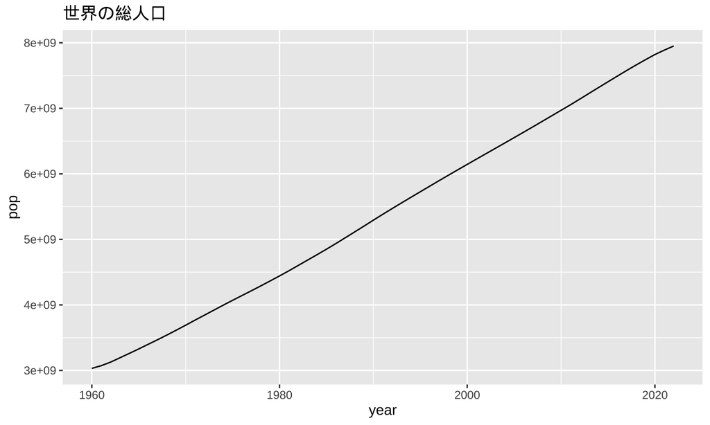

```r
df_pop |> filter(country == "World") |>
  ggplot(aes(year, pop)) + geom_line() +
  labs(title = "世界の総人口")
```

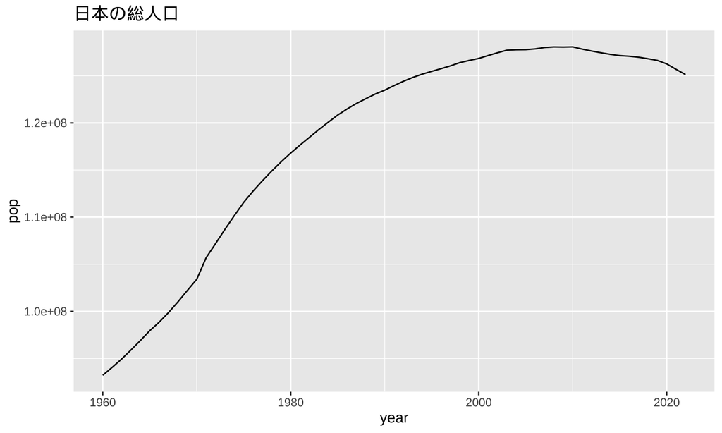

```r
df_pop |> filter(country == "Japan") |>
  ggplot(aes(year, pop)) + geom_line() +
  labs(title = "日本の総人口")
```

**練習：Germany と ドイツの部分を他の国名に変えてみてください。**

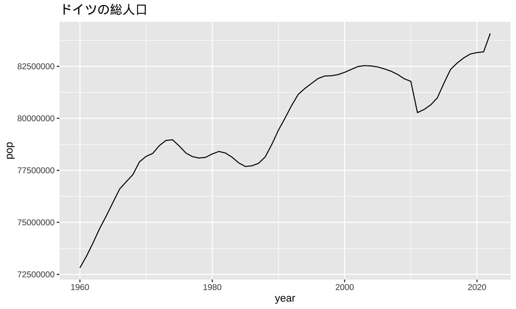

```r
COUNTRY <- "Germany"
df_pop |> filter(country == COUNTRY) |>
  ggplot(aes(year, pop)) + geom_line() +
  labs(title = "ドイツの総人口")
```

## 2022年の総人口の多い順

```r
df_pop |> filter(!(iso2c %in% REGION)) |> filter(year == 2022) |>
  arrange(desc(pop))
```

| country | iso2c | iso3c | year | pop |
| --- | --- | --- | --- | --- |
| India | IN | IND | 2022 | 1417173173 |
| China | CN | CHN | 2022 | 1412175000 |
| United States | US | USA | 2022 | 333287557 |
| Indonesia | ID | IDN | 2022 | 275501339 |
| Pakistan | PK | PAK | 2022 | 235824862 |
| Nigeria | NG | NGA | 2022 | 218541212 |
| Brazil | BR | BRA | 2022 | 215313498 |
| Bangladesh | BD | BGD | 2022 | 171186372 |
| Russian Federation | RU | RUS | 2022 | 143555736 |
| Mexico | MX | MEX | 2022 | 127504125 |

[output cut: 207 more lines]

## 2022年の総人口の TOP 11

```r
pop_top11 <- df_pop |> filter(!(iso2c %in% REGION)) |> filter(year == 2022) |>
  arrange(desc(pop)) |> slice_head(n=11) |> pull(iso2c)
pop_top11
```

```
##  [1] "IN" "CN" "US" "ID" "PK" "NG" "BR" "BD" "RU" "MX" "JP"
```

```r
dput(pop_top11)
```

```
## c("IN", "CN", "US", "ID", "PK", "NG", "BR", "BD", "RU", "MX",
## "JP")
```

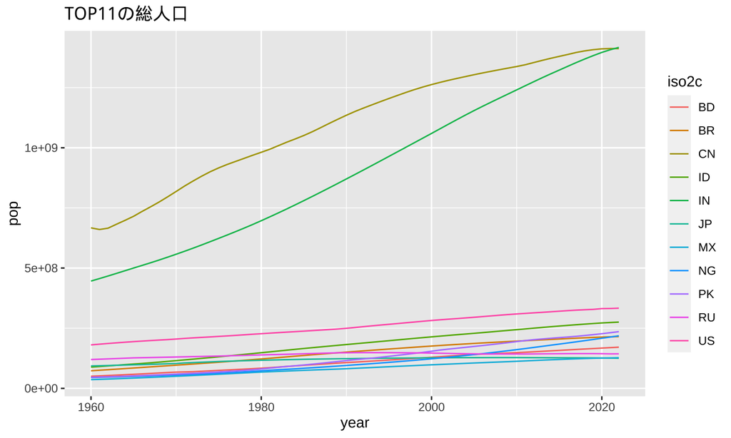

```r
df_pop |> filter(iso2c %in% pop_top11) |>
  ggplot(aes(year, pop, color = iso2c)) + geom_line() + labs(title = "TOP11の総人口")
```

## 中国とインド以外のTOP11 の人口推移

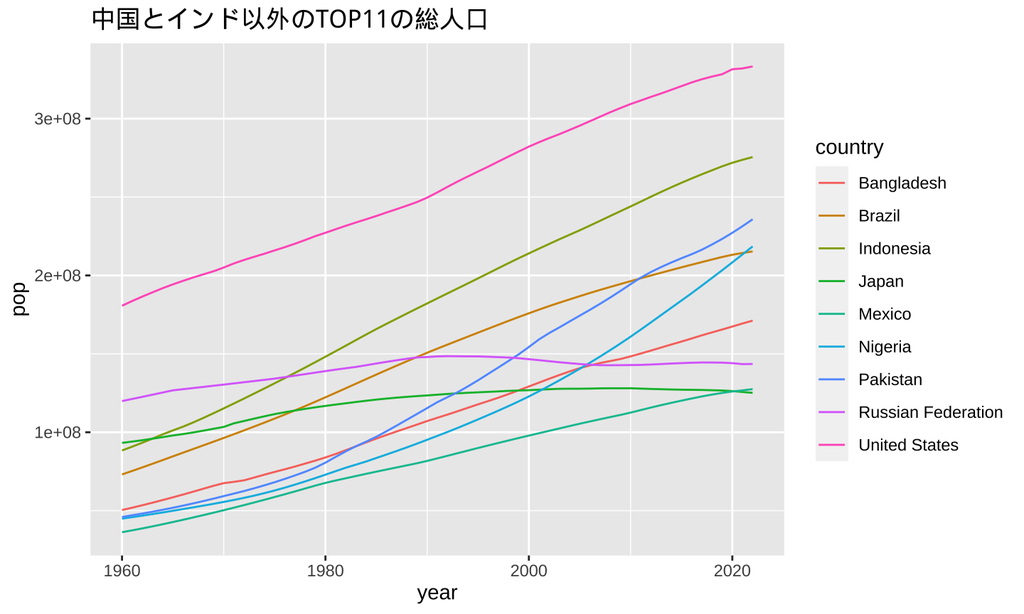

```r
df_pop |> filter(iso2c %in% pop_top11) |>
  filter(!(iso2c %in% c("CN", "IN"))) |>
  ggplot(aes(year, pop, color = country)) + geom_line() +
  labs(title = "中国とインド以外のTOP11の総人口")
```

## 地域ごとの人口推移

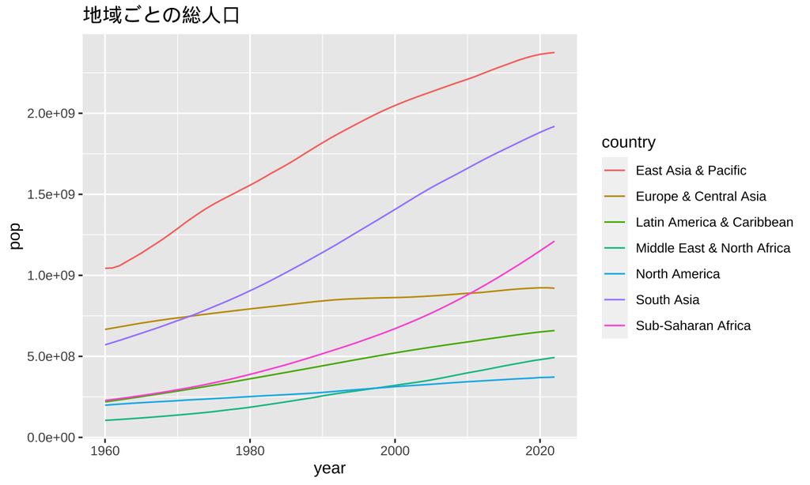

```r
df_pop |> filter(country %in% c("South Asia", "Europe & Central Asia", "Middle East & North Africa",
"East Asia & Pacific", "Sub-Saharan Africa", "Latin America & Caribbean", "North America")) |>
  ggplot(aes(year, pop, color = country)) + geom_line() + labs(title = "地域ごとの総人口")
```

## 変形

wide データを long データに変形します。いずれ説明します。

```r
df_pop_long <- df_pop_related |>
  pivot_longer(pop:old, names_to = "name", values_to = "value")
```

## 出生率と死亡率

出生率（千人）Birth rate, crude (per 1,000 people)：SP.DYN.CBRT.IN [[Link](https://data.worldbank.org/indicator/SP.DYN.CBRT.IN)]

死亡率（千人）Death rate, crude (per 1,000 people)：SP.DYN.CDRT.IN [[Link](https://data.worldbank.org/indicator/SP.DYN.CDRT.IN)]

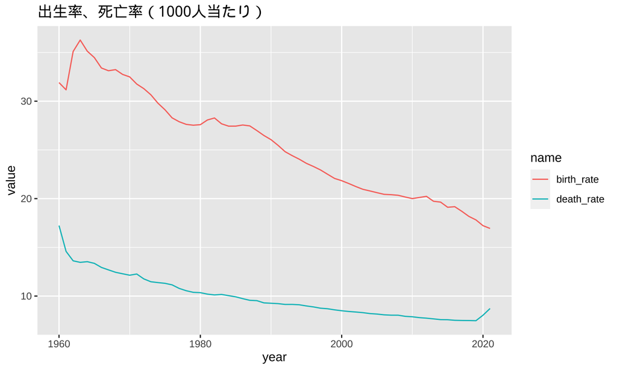

```r
df_pop_long |> filter(name %in% c("birth_rate", "death_rate")) |>
  filter(country == "World") |> drop_na(value) |> # NA value を削除
  ggplot(aes(year, value, col = name)) + geom_line() +
  labs(title = "出生率、死亡率（1000人当たり）")
```

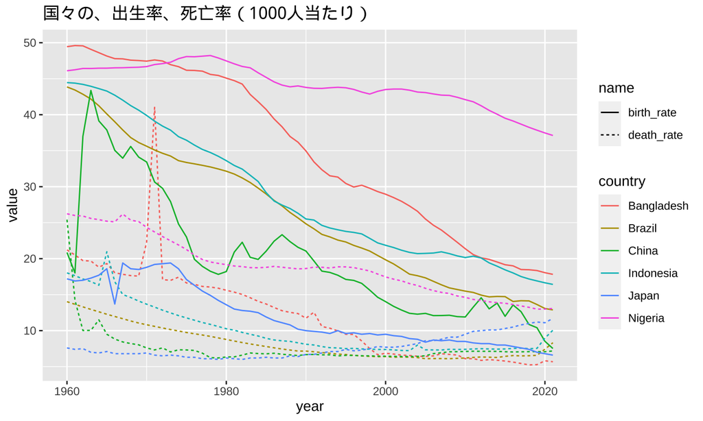

```r
df_pop_long |> filter(name %in% c("birth_rate", "death_rate")) |>
  filter(iso2c %in% c("BD", "BR", "CN", "ID", "NG", "JP")) |> drop_na(value) |>
  ggplot(aes(year, value, col = country, linetype = name)) +
  geom_line() + labs(title = "国々の、出生率、死亡率（1000人当たり）")
```

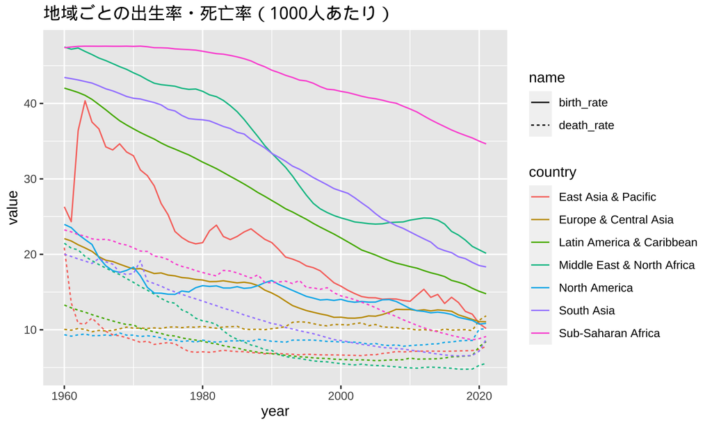

```r
df_pop_long |> filter(name %in% c("birth_rate", "death_rate")) |>
  filter(iso2c %in% c("Z4", "Z7", "ZJ", "ZQ", "XU", "8S", "ZG")) |> drop_na() |>
  ggplot(aes(year, value, col = country, linetype = name)) +
  geom_line() + labs(title = "地域ごとの出生率・死亡率（1000人あたり）")
```

## 扶養家族の労働人口に対する割合

若年労働人口率 Age dependency ratio, young (% of working-age population)：SP.POP.DPND.YG [[Link](https://data.worldbank.org/indicator/SP.POP.DPND.YG)]

年齢別扶養比率（若年）は、15歳未満の扶養家族の、15歳から64歳までの生産年齢人口に対する比率である。データは、生産年齢人口100人当たりの扶養家族の割合で示されている。

高齢者労働人口率 Age dependency ratio, old (% of working-age population)：SP.POP.DPND.OL [[Link to Metadata](https://databank.worldbank.org/metadataglossary/health-nutrition-and-population-statistics/series/SP.POP.DPND.OL)]

年齢別扶養比率（高齢）は、生産年齢人口（15～64歳）に対する高齢扶養家族（64歳以上）の比率。データは、生産年齢人口100人当たりの扶養家族の割合で示されている。

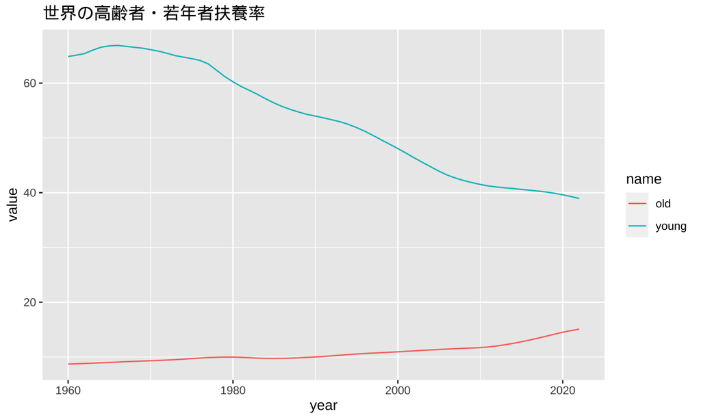

```r
df_pop_long |> filter(name %in% c("young", "old")) |>
  filter(country == "World") |>
  ggplot(aes(year, value, col = name)) + geom_line() +
  labs(title = "世界の高齢者・若年者扶養率")
```

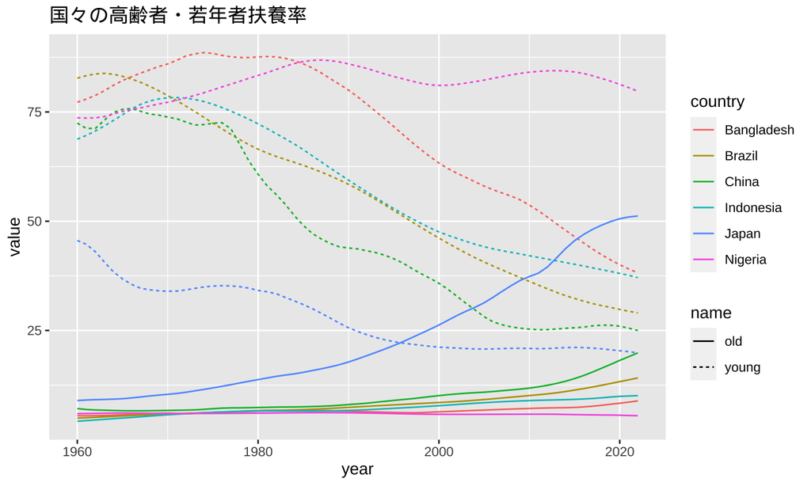

```r
df_pop_long |> filter(name %in% c("young", "old")) |>
  filter(iso2c %in% c("BD", "BR", "CN", "ID", "NG", "JP")) |>
  ggplot(aes(year, value, col = country, linetype = name)) +
  geom_line() + labs(title = "国々の高齢者・若年者扶養率")
```

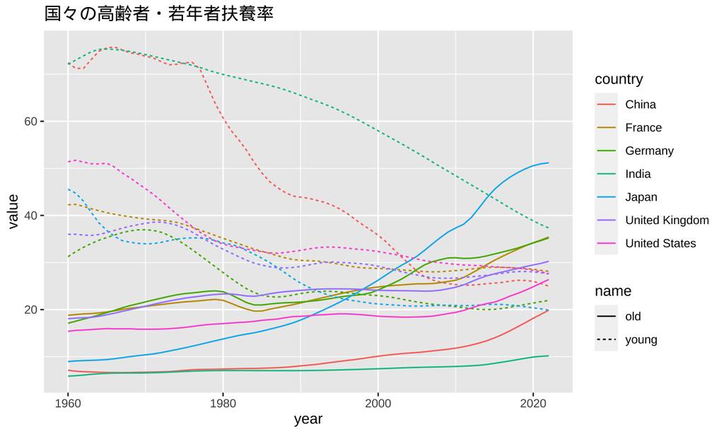

```r
df_pop_long |> filter(name %in% c("young", "old")) |>
  filter(iso2c %in% c("US", "GB", "CN", "DE", "FR", "JP", "IN")) |>
  ggplot(aes(year, value, col = country, linetype = name)) +
  geom_line()　+ labs(title = "国々の高齢者・若年者扶養率")
```

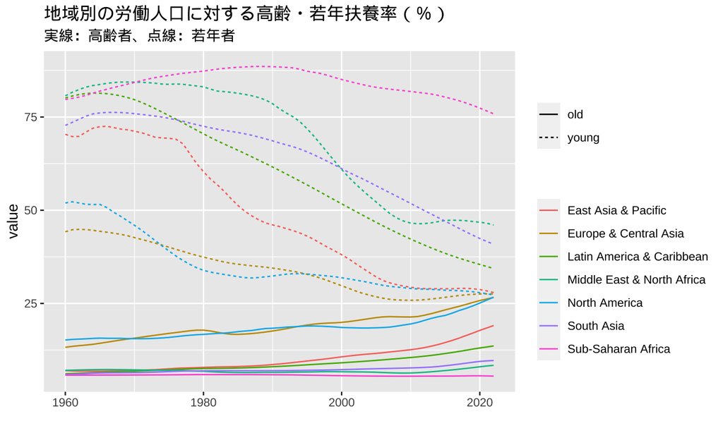

```r
df_pop_long |> filter(name %in% c("young", "old")) |>
  filter(country %in% c("South Asia", "Europe & Central Asia", "Middle East & North Africa",
"East Asia & Pacific", "Sub-Saharan Africa", "Latin America & Caribbean", "North America")) |>
  ggplot(aes(year, value, col = country, linetype = name)) +
  geom_line() + labs(title = "地域別の労働人口に対する高齢・若年扶養率（％）",
       subtitle = "実線：高齢者、点線：若年者", x = "", col = "", linetype = "")
```

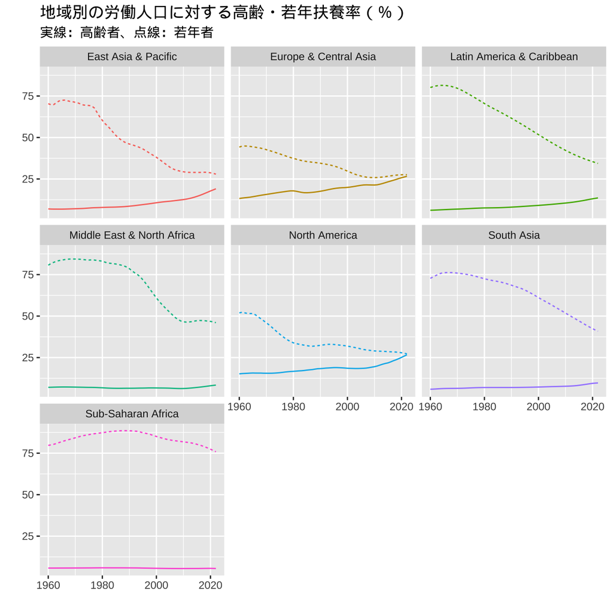

```r
df_pop_long |> filter(name %in% c("young", "old")) |>
  filter(country %in% c("South Asia", "Europe & Central Asia", "Middle East & North Africa",
"East Asia & Pacific", "Sub-Saharan Africa", "Latin America & Caribbean", "North America")) |>
  ggplot(aes(year, value, col = country, linetype = name)) +
  geom_line() + facet_wrap(~country) + theme(legend.position = "none") +
  labs(title = "地域別の労働人口に対する高齢・若年扶養率（％）",
       subtitle = "実線：高齢者、点線：若年者", x = "", y = "")
```

Default is **fig.** **width = 7 and fig.** **height = 5**

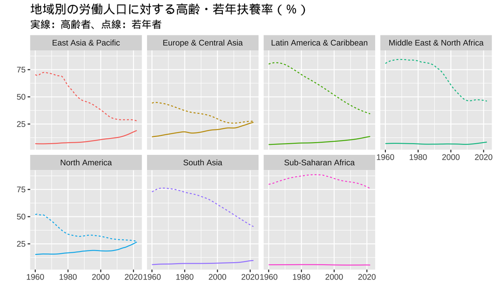

```r
df_pop_long |> filter(name %in% c("young", "old")) |>
  filter(country %in% c("South Asia", "Europe & Central Asia", "Middle East & North Africa",
"East Asia & Pacific", "Sub-Saharan Africa", "Latin America & Caribbean", "North America")) |>
  ggplot(aes(year, value, col = country, linetype = name)) +
  geom_line() + facet_wrap(~country, 2,4) + theme(legend.position = "none") +
  labs(title = "地域別の労働人口に対する高齢・若年扶養率（％）",
       subtitle = "実線：高齢者、点線：若年者", x = "", y = "")
```

## 復習

- パッケージ（Package）の利用：
  - インストール（installation）：Tools > Install Packages
  - ロード（load）`library(tidyverse); library(WDI); library(showtext)`
- データの取得：`WDI(indicator = c(pop = "SP.POP.TOTL"))`
- 特定の行の取得：`filter(), drop_na(), distinct()`
- 折れ線グラフ
  - `ggplot(aes(x = year, y = pop) + geom_line()`
  - `ggplot(aes(x = year, y = pop, col = country) + geom_line()`

## 課題

提出はしなくて良いですが、ぜひ実際に手を動かして実行してください。

1. WDI のサイトで、興味のある指標の、名前と、WDI コードを選んでください。できれば、選択した理由も記録してください。
2. Germany と ドイツの部分を他の国名に変えてみてください。
3. 1960年の総人口が多い順に五番目までリストしてみましょう。
4. いくつかの国を選択して、総人口の推移のグラフを描いてください。
5. 国を選択して、出生率、死亡率のグラフを描いてください。
6. いくつかの国または地域の、出生率、死亡率のグラフを描いてください。
7. 国を選択して、高齢者・若年者の扶養率のグラフを描いてください。
8. いくつかの国または地域の、高齢者・若年者の扶養率のグラフを描いてください。

## 参考文献

1. 「みんなのデータサイエンス - Data Science for All」[[はじめてのデータサイエンス](https://icu-hsuzuki.github.io/ds4aj/first-example.html#first-example)]
   - 導入として、GDP（国内総生産）のデータを使って説明しています。
2. Posit Primers: The Basics 対話型の演習サイトの最初 [[Link](https://posit.cloud/learn/primers/1)]
   1. [Visualization Basics](https://posit.cloud/learn/primers/1.1)
   2. [Programming Basics](https://posit.cloud/learn/primers/1.2)
3. RStudio IDE Cheat Sheet. 早見表です。印刷して使うために、PDF も提供しています。[[Site Link](https://rstudio.github.io/cheatsheets/html/rstudio-ide.html)]